# Lab 7 - Dynamic Programming - Power Plant

Information on group members:

1. Student ID, Name and last name
2. Student ID, Name and last name

```python
%matplotlib inline

from sympy.interactive import printing
printing.init_printing(use_latex=True)

import matplotlib.pyplot as plt
import sympy as sym
from sympy import *
import numpy as np
```

This exercise is inspired by Ex. 2 in the Exercises.pdf file. You have to set operating levels for a power plant for consecutive two-months in a way that minimizes the operating costs (using dynamic programming). Before going to the exercise, it is recommended to get acquainted with a Python library for symbolic calculations - SymPy, which can be particularly helpful for solving this task.

# Mini tutorial on SymPy

SymPy is a library for performing symbolic calculations instead of numerical. It allows defining symbols, functions, expressions, equations and performing various operations on them. The examples of such operations that can help solve this exercise are given below. Note that due to lines:  
from sympy.interactive import printing  
printing.init_printing(use_latex=True)  
located in the first cell of this notebook, the symbols can be printed using latex, improving hence readability

**Defining symbols:**

```python
z1, z2 = symbols("z1 z2")
# or z = symbols("z1 z2")
```

**Printing a symbol using Latex:**

```python
z1
```

$\displaystyle z_{1}$

**Defining an expression:**

```python
2*z1 + (10-z2)**2
```

$\displaystyle 2 z_{1} + \left(10 - z_{2}\right)^{2}$

**Expanding the expression:**

```python
expand(2*z1 + (10-z2)**2)
```

$\displaystyle 2 z_{1} + z_{2}^{2} - 20 z_{2} + 100$

**Simplifying the expression:**

```python
e = simplify(expand(2*z1 + (10-z2)**2 - (5+z1)**2))
e
```

$\displaystyle - z_{1}^{2} - 8 z_{1} + z_{2}^{2} - 20 z_{2} + 75$

**Substituting a variable with a value in the expression:**

```python
e = 2*z1 + (10-z1)**2
v = e.evalf(subs={z1: 10})
print(v)
```

```
20.0000000000000
```

**Substituting a variable with another variable or value:**

```python
e = 2*z1 + (10-z2)**2
e.subs(z2, z1)
```

$\displaystyle 2 z_{1} + \left(10 - z_{1}\right)^{2}$

**Finding a (partial) derivative:**

```python
e = 2*z1 + (10-z2)**2
d = diff(e, z2)
d
```

$\displaystyle 2 z_{2} - 20$

**Solving an equation:**

```python
e = 2*z1 + (10-z2)**2
d = diff(e, z2)
v = solve(Eq(d, 0), z2)
print(v)
```

```
[10]
```

# Exercise

Below given is the data. In contrast to the exercise shown in the Exercise.pdf file, note that all pairs of all 12 months are considered stages in this notebook.

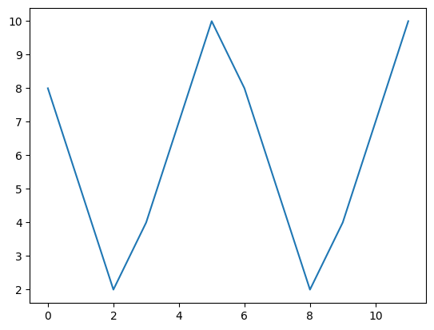

```python
months = ["Jan-Feb", "Mar-Apr", "May-Jun", "Jul-Aug", "Sep-Oct", "Nov-Dec"]

### min requested operating level (1-10) + allowable bounds
request = [8,5,2,4,7,10]
bounds = [[request[i], 10] for i in range(6)]

plt.plot([i for i in range(12)], request + request, label='linear')
plt.show()
```

**Cost:** Working above the required level - cost in a generic form:

```python
xi, ri, mi1 = symbols("x_i r_i m_{i1}")
cost_above = mi1*(xi-ri)
cost_above #mi1 = multiplicator, #xi = operating level #ri = requirement (lower bound)
```

$\displaystyle m_{i1} \left(- r_{i} + x_{i}\right)$

You can do c = cost_above.copy() and then c.subs, replacing variables with values (m, p, r) or other variables (r):

```python
x1 = symbols("x1")
c = cost_above.copy()
c = c.subs(xi, x1)
c = c.subs(mi1, 1)
c = c.subs(ri, 100)
c
```

$\displaystyle x_{1} - 100$

Below are provided m parameter values for each month:

```python
mv1 = [2, 8, 10, 12, 10, 6 ]
```

**Cost:** Chaging the operating level - cost in a generic form:

```python
si, mi2, pi = symbols("s_{i} m_{i2} p_i")
cost_change = mi2*(xi-si)**pi
cost_change #mi2 = multiplicator, #pi = exponent #xi = operating level (i-th month) #s_{i} = state: operating level ((i-1)-th month)
cost_change
```

$\displaystyle m_{i2} \left(- s_{i} + x_{i}\right)^{p_{i}}$

Below are provided m and p parameter values for each month:

```python
mv2 = [6, 4, 1, 1, 3, 5]
pv = [2, 2, 2, 2, 2, 2]
```

# Solution:

Apart from finding optimal operating levels for each month, plot these values along with the lower bounds for each month in order to show how they change in time.  
Hints:

- the optimal cost = 135.42
- there is no situation when the minima for first derivatives are outside allowable bounds (but test it anyway)

After obtaining and plotting the solution, check what would happen is you change the mv1[2] parameter to 5.

```python
# Define symbolic variables with SymPy
f7_, f6_, f5_, f4_, f3_, f2_, f1_ = symbols("f7_ f6_ f5_ f4_ f3_ f2_ f1_")
f6, f5, f4, f3, f2, f1 = symbols("f6 f5 f4 f3 f2 f1")
x6, x5, x4, x3, x2, x1 = symbols("x6 x5 x4 x3 x2 x1")

df5_, df4_, df3_, df2_, df1_ = symbols("df5_ df4_ df3_ df2_ df1_")
```

```python
x6=max(request)
f7_=0
```

```python
globals()[f"x{2}"]
```

$\displaystyle x_{2}$

```python
f6=mv2[-1]*(x6-x5)**(pv[-1])+mv1[-1]*(x6-request[-1])+f7_
```

```python
f6_=f6
```

```python
f6_
```

$\displaystyle 5 \left(10 - x_{5}\right)^{2}$

```python
for i in range(5,0,-1):
    if i==1:
        previous=6
    else:
        previous=i-1
    print(previous)
    globals()[f"f{i}"]=mv2[i]*(globals()[f"x{i}"]-globals()[f"x{previous}"])**(pv[i])+mv1[i]*(globals()[f"x{i}"]-request[i])+globals()[f"f{i+1}_"]
    globals()[f"df{i}"]= diff(globals()[f"f{i}"], globals()[f"x{i}"])
    v = solve(Eq(globals()[f"df{i}"], 0), globals()[f"x{i}"])
    globals()[f"f{i}_"]=globals()[f"f{i}"].subs(globals()[f"x{i}"],v[0])
    globals()[f"x{i}"]=v[0]
```

```
4
3
2
1
6
```

```python
f1
```

$\displaystyle \frac{798 x_{1}}{41} + 5 \left(\frac{571}{205} - \frac{3 x_{1}}{41}\right)^{2} + \left(\frac{120}{41} - \frac{15 x_{1}}{41}\right)^{2} + 3 \left(\frac{122}{41} - \frac{5 x_{1}}{41}\right)^{2} + 5 \left(\frac{694}{205} - \frac{3 x_{1}}{41}\right)^{2} + \left(- \frac{15 x_{1}}{41} - \frac{85}{41}\right)^{2} + 4 \left(x_{1} - 10\right)^{2} - \frac{34954}{205}$

```python
df1
```

$\displaystyle \frac{358 x_{1}}{41} - \frac{2782}{41}$

```python
f1_
```

$\displaystyle \frac{90727}{895}$

```python
f4_
```

$\displaystyle \frac{78 x_{3}}{11} + 5 \left(\frac{166}{55} - \frac{3 x_{3}}{11}\right)^{2} + 3 \left(\frac{37}{11} - \frac{5 x_{3}}{11}\right)^{2} + 5 \left(\frac{199}{55} - \frac{3 x_{3}}{11}\right)^{2} - \frac{3194}{55}$